# Projeto Integrador - Livros de Data Science e Estatística da Amazon

Amábile Galdino Leandro

Eduardo Lopes Cock

24/03/2021

## Link da apresentação

https://www.youtube.com/watch?v=cmrgKopIG64

## Introdução

Devido ao nosso interesse por literatura e livros no geral e ao fato de que ambos os integrantes da dupla estão matriculados na graduação em Estatística da UFPR, nós optamos por juntar os dois argumento e coletar dados sobre livros relacionados a estatística e ciência de dados. Definido o assunto, nosso objetivo é analisar quais fatores interferem no preço dos livros em questão. Antes da análise foram estabelecidas algumas hipóteses sobre o assunto:

- Livros de capa dura tendem a ser mais caros, devido a necessidade de mais material para a impressão e por serem usado com mais frequência em edições especiais;
- Livros importados tendem a ser mais caros, devido a dependência do preço do dolar ;
- Livros com mais páginas também apresentam preço mais elevado, devivo a necessidade de mais material(folhas de papel) para a impressão.

## Materiais e métodos

### Coleta dos dados

Os dados analisados foram extraídos do site Amazon.com.br no dia 07/03/2021 com informações sobre livros relacionados a Data Science e Estatística. Esta coleta foi feita utilizando Web Scraping com o auxílio do *software* Octoparse 8. Após a coleta dos dados, foi realizada uma pré-limpeza com o objetivo de retirar os livros presentes na base que não tinham relação com o tema. Feito isso, sobraram ao todo 461 observações e 11 variáveis. As variáveis são:

- **Titulo**: Título do livro
- **Preco**: Preço do livro
- **TipoLivro**: Material da capa do livro (brochura ou capa dura)
- **Avaliacao**: Avaliação que os compradores deram ao livro
- **nAvaliacao**: Número de avaliações que o livro teve no site da Amazon
- **Paginas**: O número de páginas do livro
- **Idioma**: Idioma no qual o livro está sendo vendido
- **Editora**: Editora na qual o livro foi publicado
- **Dimensao**: Largura, altura e espessura do livro
- **Data**: Data de publicação do livro
- **Dias**: Dias desde a publicação até o dia da extração da base (07.03.2021)

### Modelagem estatística

A primeira coisa feita neste trabalho foi a análise exploratória dos dados, para uma maior compreensão da base antes da construção do modelo. Para a etapa de análise exploratória foi usado os pacotes Tidyverse e DataExplorer.

Para o modelo múltiplo aditivo, primeiro realizamos o ajuste, seguido por uma análise de diagnóstico com gráficos de resíduos, transformação dos dados usando Box-Cox e seleção do modelo utilizando o coeficiente de determinação ajustado.

Para o ajuste do modelo foi utilizado a função `lm()`, na análise de diagnóstico serão utilizados os gráficos para análise de resíduos e as funções `influencePlot()`, `qqPlot()`, `rstandard()` e `plot()`, para a transformação das variáveis será utilizado o método de Box-Cox e como critério de qualidade do ajuste será considerado o coeficiente de determinação ajustado.

## Resultados e discussões

### Análise Exploratória

Antes da realização da análise exploratória dos dados, realizamos o tratamento do nosso conjunto de dados. Nesta etapa foram retiradas 3 variáveis (Dimensão, Data, Editora) que não seriam proveitosas para a nossa análise devido a estrutura dos dados, além disso também realizamos a retirada de todas as linhas que contem NA.

#### Carregamento e tratamentos

```r
library(tidyverse)
library(DataExplorer)
library(corrplot)
library(MASS)
library(car)
library(readr)

base <- read.csv("C:/Users/Amábile/Documents/Estatística/Regressão Linear/PI/Amazon.csv", header = TRUE, sep = ",", dec = ".")
base <-subset(base, select = -c(Dimensao, Data, Editora))## excluindo colunas que não serâo usadas
str(base)
```

```
## 'data.frame':    461 obs. of  8 variables:
##  $ Titulo    : chr  "#MakeoverMonday: Improving How We Visualize and Analyze Data. One Chart at a Time" "A First Course in Bayesian Statistical Methods" "A Hands-On Introduction to Data Science" "A Human's Guide to Machine Intelligence: How Algorithms Are Shaping Our Lives and How We Can Stay in …
##  $ Preco     : num  184 359.2 326.7 90.6 369.8 ...
##  $ TipoLivro : chr  "Capa Comum" "Capa Comum" "Capa dura" "Capa Comum" ...
##  $ Avaliacao : num  4.6 4 4.9 4.7 4.6 3.7 4.4 4.8 NA NA ...
##  $ nAvaliacao: int  90 35 26 46 140 7 8 85 NA NA ...
##  $ Paginas   : int  496 284 424 272 522 900 391 604 406 350 ...
##  $ Idioma    : chr  "Ingles" "Ingles" "Ingles" "Ingles" ...
##  $ Dias      : int  825 3762 340 363 1045 5316 146 648 -111 -512 ...
```

```r
summary(base)## medidas resumo
```

```
##     Titulo              Preco         TipoLivro           Avaliacao
##  Length:461         Min.   :  19.5   Length:461         Min.   :2.200
##  Class :character   1st Qu.: 159.8   Class :character   1st Qu.:4.300
##  Mode  :character   Median : 289.2   Mode  :character   Median :4.500
##                     Mean   : 348.9                      Mean   :4.392
##                     3rd Qu.: 430.3                      3rd Qu.:4.700
##                     Max.   :1690.3                      Max.   :5.000
##                     NA's   :10                          NA's   :93
##    nAvaliacao        Paginas          Idioma               Dias
##  Min.   :   1.0   Min.   :  42.0   Length:461         Min.   : -512
##  1st Qu.:  14.0   1st Qu.: 276.0   Class :character   1st Qu.:  207
##  Median :  44.5   Median : 354.0   Mode  :character   Median :  724
##  Mean   : 161.5   Mean   : 397.9                      Mean   : 1303
##  3rd Qu.: 139.2   3rd Qu.: 488.0                      3rd Qu.: 1679
##  Max.   :4337.0   Max.   :1292.0                      Max.   :18695
##  NA's   :93       NA's   :18
```

```r
### retirada dos NA do conjunto de dados
dados<- na.omit(base)
summary(dados)
```

```
##     Titulo              Preco         TipoLivro           Avaliacao
##  Length:352         Min.   :  19.5   Length:352         Min.   :2.200
##  Class :character   1st Qu.: 145.7   Class :character   1st Qu.:4.300
##  Mode  :character   Median : 261.8   Mode  :character   Median :4.500
##                     Mean   : 283.3                      Mean   :4.394
##                     3rd Qu.: 364.7                      3rd Qu.:4.700
##                     Max.   :1289.6                      Max.   :5.000
##    nAvaliacao        Paginas          Idioma               Dias
##  Min.   :   1.0   Min.   :  42.0   Length:352         Min.   :  -23.0
##  1st Qu.:  15.0   1st Qu.: 288.0   Class :character   1st Qu.:  508.5
##  Median :  45.5   Median : 380.0   Mode  :character   Median :  988.0
##  Mean   : 164.7   Mean   : 413.1                      Mean   : 1546.3
##  3rd Qu.: 141.5   3rd Qu.: 503.5                      3rd Qu.: 1861.5
##  Max.   :4337.0   Max.   :1292.0                      Max.   :18695.0
```

#### Numéricas

A princípio realizaremos uma análise com o objetivo de conhecer e identificar as principais características do nosso conjunto de dados. Primeiramente iniciaremos a nossa análise com as variáveis numéricas.

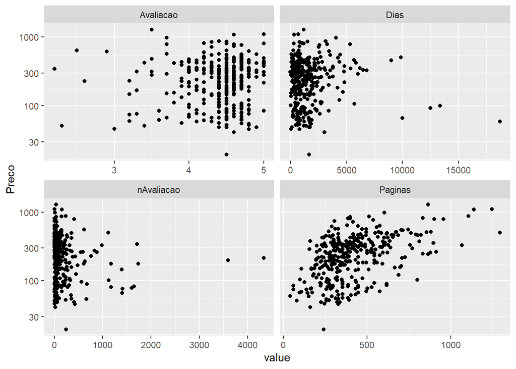

```r
### apenas numericas
dados_num <- subset(dados, select = -c(TipoLivro, Idioma, Titulo))
### dispersão em relação ao preço
tb2 <- dados_num %>%
  gather(key = "variable", value = "value", -Preco)

#### comportamento do conjunto de dados
ggplot(data = tb2,
       mapping = aes(x = value, y = Preco)) +
  facet_wrap(facets = ~variable, scale = "free_x") +
  scale_y_log10() +
  geom_point()
```

Nesta visualização trazemos a dispersão dos dados em relação a nossa variável resposta *Preco*. Já neste gráfico conseguimos observar algumas características interessantes a respeito dos nossos dados.

Tanto *Dias* quanto *nAvaliacao* possuem algumas observações muito distantes dos demais dados observados, sendo possíveis outliers que venham a interferir no modelo.

Outro ponto a ser observado é a relação entre Avaliação e Preço, apenas com o gráfico de dispersão é difícil identificar qual o comportamento no conjunto de dados.

Por outro lado, variáveis *Paginas* é a que apresenta um comportamento razoável, apesar de ser possível observar alguns pontos distantes dos demais dados, isso não parece interferir na visualização.

Em busca de uma maior compreensão sobre os nossos dados, vamos plotar os gráficos com a reta ajustada:

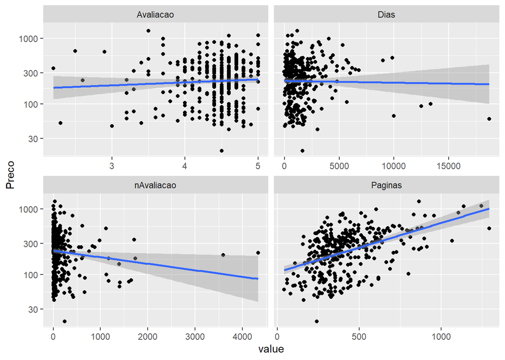

```r
#### ajuste da reta para cada uma das variáveis
ggplot(data = tb2,
       mapping = aes(x = value, y = Preco)) +
  facet_wrap(facets = ~variable, scale = "free_x") +
  scale_y_log10() +
  geom_point() +
  geom_smooth(method = "lm")
```

Com a plotagem realmente fica evidente que os outliers estão interferindo no ajuste da reta dos gráficos de número de *Avaliacao* e *Dias*, além disso vale mencionar que devido aos dados estarem muito concentrados próximo ao eixo y, isso também dificulta a observação da disperção.

Em relação a *Avaliacao*, podemos observar que a inclinação na reta ajustada é pouco significativa, isso demonstra que talvez as avaliações não venham realmente a interferir no preço.

##### Tranformação

Para tentar visualizar os dados com mais precisão, optamos por uma transformação para raiz cúbica.

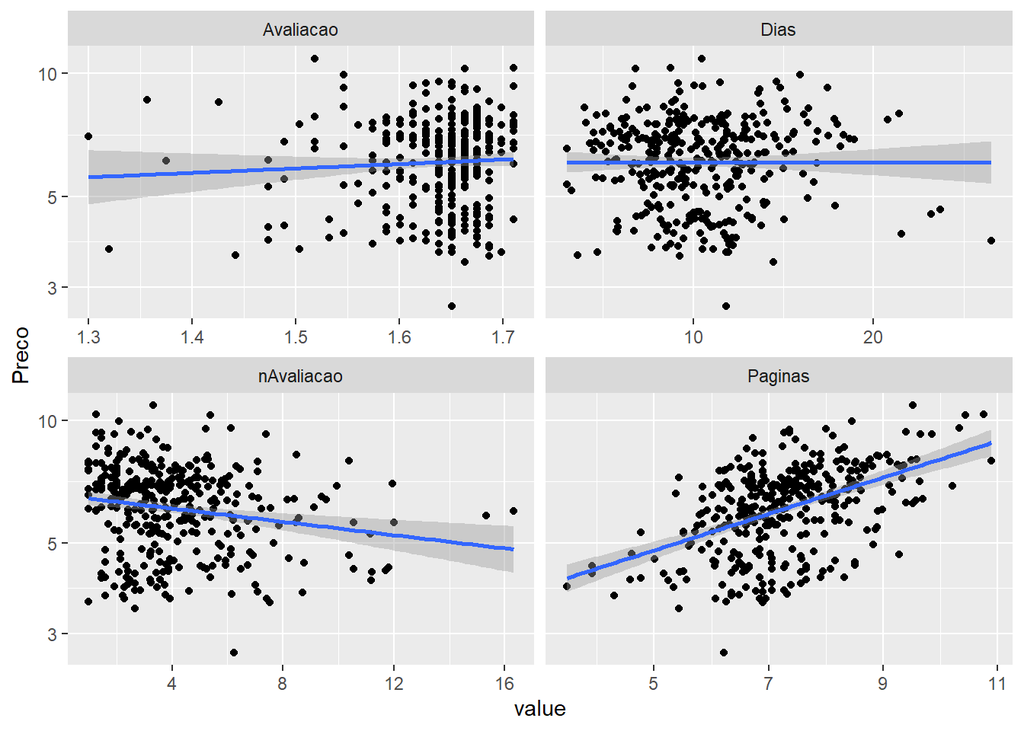

```r
##Transformação
transtb2 <- tb2 %>%
  mutate(value = value^(1/3)) %>%
  mutate(Preco = Preco^(1/3))


ggplot(data = transtb2,
       mapping = aes(x = value, y = Preco)) +
  facet_wrap(facets = ~variable, scale = "free_x") +
  scale_y_log10() +
  geom_point() +
  geom_smooth(method = "lm")
```

A partir da transformação em *nAvaliacao* podemos identificar com mais clareza um comportamento linear negativo quando traçada a reta. Apesar de ainda ser possível identificar os outliers, a discrepância entre os demais pontos reduziu após a mudança de escala.

Analisando a variável *Paginas* observamos um comportamento crescente do nosso conjunto de dados antes mesmo da transformação. Quando mudamos a escala do gráfico a reta fica melhor ajustada, sendo possível observar uma otimização no cruzamento da reta.

Na variável *Dias*, após a transformação é possível enxergar o comportamento dos dados com mais clareza, já que as observações deixam de apresentar uma concentração próxima ao eixo y. Porém mesmo após a transformação vemos que o ajuste da reta é muita semelhante a uma constante, indicando que possívelmente essa variável não interfira significativamente no preço do livro.

Algo semelhante é visto na variável *Avaliacao*, mesmo após a transformação os dados se assemelham ao que eram antes da mudança de escala e como na variável *Dias* a reta apresenta uma leve inclinação, sendo possível concluir que talvez a avaliação não interfira no preço do livro.

#### Categóricas

Além das variáveis numéricas, as variáveis categórias também podem ser importantes para o ajuste do nosso modelo. Aqui faremos uma breve análise sobre as variáveis categóricas que pretendemos usar no modelo.

##### Tipo de Livro

Começaremos com a variável *TipoLivro* que está categorizada em dois níveis, são eles: Capa Dura e Capa Comum.

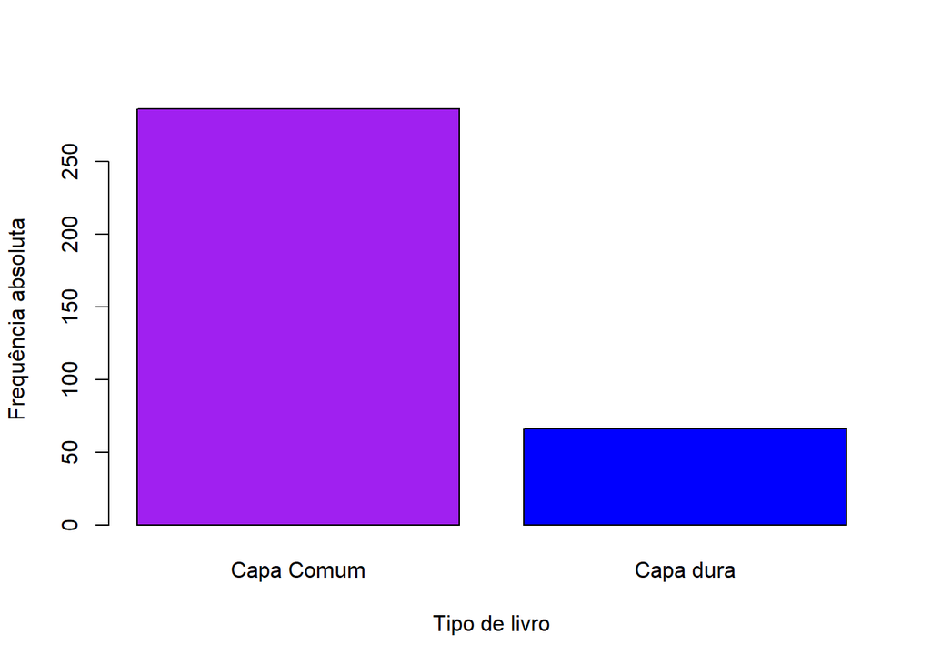

```r
cate.livro<- table(dados$TipoLivro)

barplot(cate.livro,
        xlab = "Tipo de livro",
        ylab = "Frequência absoluta",
        col = c("purple", "blue"))
```

No gráfico acima é possível observar que o nível “Capa Comum” é mais frequente no nosso conjunto de dados que “Capa dura”.

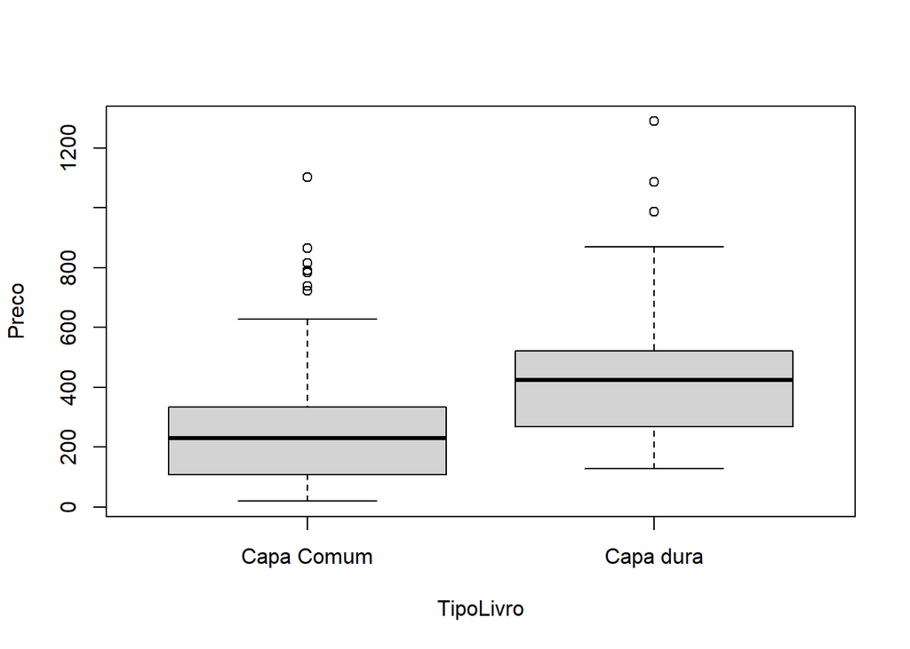

```r
boxplot(Preco ~ TipoLivro, data = dados)
```

Plotando o gráfico de boxplot, podemos observar que livros de “Capa Dura” no nosso conjunto de dados tendem a possuir um preço mais elevado comparado aos livros de “Capa Comum”. Sendo assim é possível que a variável *TipoLivro* possua relevância na construição do modelo.

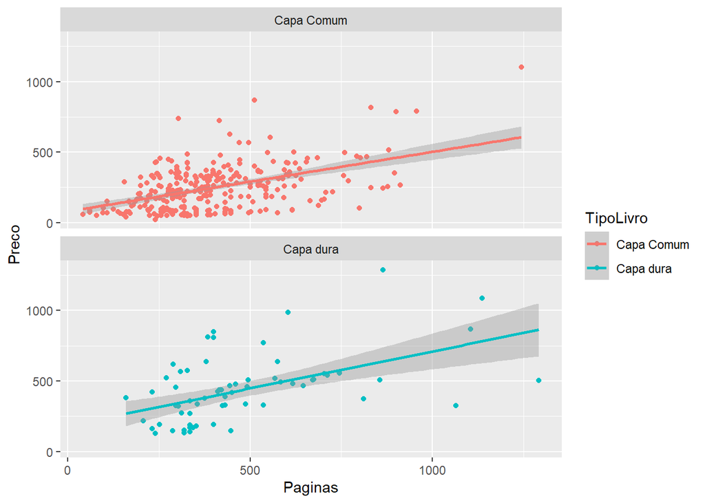

```r
ggplot(data = dados,
       mapping = aes(x = Paginas, y = Preco, color = TipoLivro)) +
  facet_wrap(facets = ~TipoLivro, nrow = 3)+
  geom_point()+
  geom_smooth(method = "lm")
```

Neste gráfico optamos por visualizar o ajuste da reta separadamente para cada conjunto de dados. Talvez por possuir um maior número de observações, é visível que o ajuste da reta para “Capa Comum” demonstra melhor o comportamento dos dados. Enquanto para “Capa Dura”, os pontos apresentam maior dispersão em torno da reta ajustada.

##### Idioma

Agora passando para a análise da variável *Idioma*, serão analisados os níveis “Ingles” e “Portugues” presentes na base pós-tratamento dos dados.

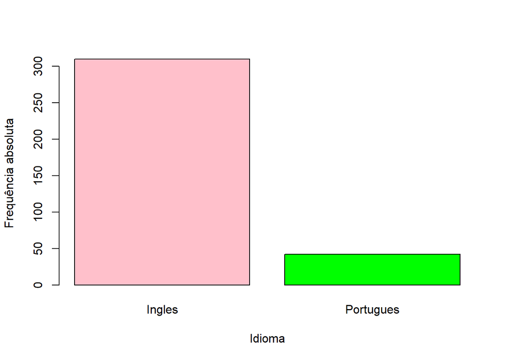

```r
cate.idioma<- table(dados$Idioma)

barplot(cate.idioma,
        xlab = "Idioma",
        ylab = "Frequência absoluta",
        col = c("pink", "green"))
```

Assim como em *TipoLivro*, primeiro analisamos a frequência de livros em inglês e português no nosso conjunto de dados. Aqui podemos observar que os livros em Inglês estão em maior quantidade na nossa base do que os em Português. Provavelmente relacionado ao fato de uma maior disponibilidade de materiais em língua inglesa sobre Ciência de Dados e Estatística.

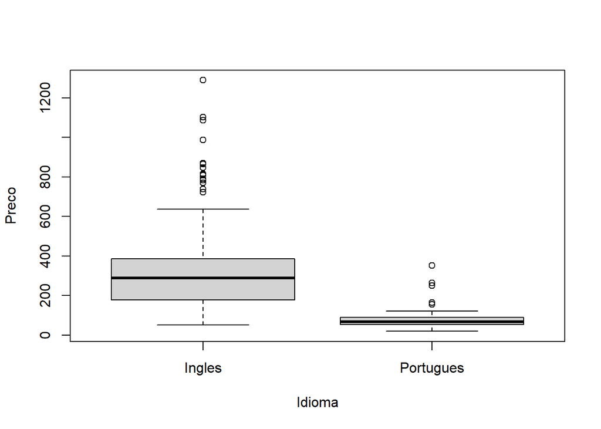

```r
boxplot(Preco ~ Idioma, data = dados)
```

Analisando o gráfico de boxplot, podemos observar que o preço de livros em inglês é maior do que o de livros em português, sendo uma informação relevante para a construção do modelo.

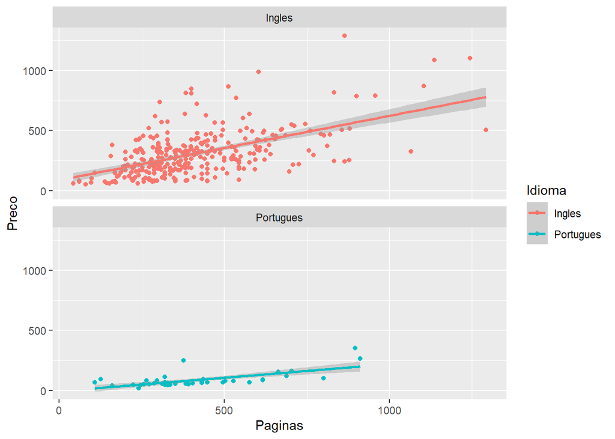

```r
## ajuste da reta com o livro separadamente
ggplot(data = dados,
       mapping = aes(x = Paginas, y = Preco, color = Idioma)) +
  facet_wrap(facets = ~Idioma, nrow = 3)+
  geom_point()+
  geom_smooth(method = "lm")
```

Para encerrar a etapa de análise das variáveis categóricas, podemos observar o ajuste da reta para cada um dos idiomas presentes na nossa base. Aparentemente ambos os npiveis apresentam um bom ajuste para a s observações

##### Correlação

Por último construímos uma matriz com o objetivo de analisar a correlação entre as variáveis.

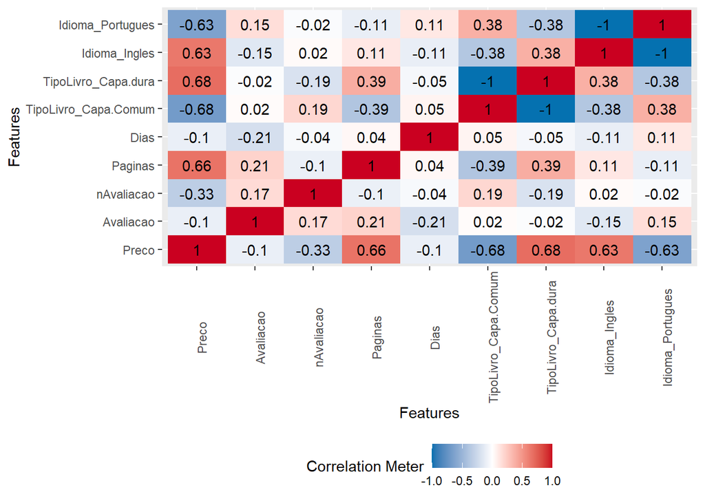

```r
dadosdummy<- subset(dados, select = -c(Titulo))
du.dados<-dummify(dadosdummy)
cor.bados<-cor(du.dados)

plot_correlation(cor.bados)
```

Aqui podemos observar que as variáveis categóricas *Idioma* e *TipoLivro*, possuem maior correlação com a nossa variável resposta *Preco*, assim como a variável preditora numérica *Paginas*. Todas elas possuem correlação superior a 0.60 sendo positivo ou negativo.

### Ajuste do modelo

Feita a análise exploratória, podemos realizar o ajuste do modelo.

```r
### Modelo m0
dados0 <- filter(dados, Preco > 0)
m0 <- lm(Preco ~ Avaliacao + Dias + nAvaliacao + Paginas + Idioma + TipoLivro, data = dados0)
summary(m0)
```

```
##
## Call:
## lm(formula = Preco ~ Avaliacao + Dias + nAvaliacao + Paginas +
##     Idioma + TipoLivro, data = dados0)
##
## Residuals:
##     Min      1Q  Median      3Q     Max
## -396.84  -84.31  -12.41   64.03  627.25
##
## Coefficients:
##                       Estimate  Std. Error t value             Pr(>|t|)
## (Intercept)         219.528479   77.582697   2.830              0.00493 **
## Avaliacao           -27.531115   18.090171  -1.522              0.12895
## Dias                 -0.003491    0.003886  -0.898              0.36969
## nAvaliacao           -0.085302    0.018977  -4.495 0.000009515016540444 ***
## Paginas               0.500604    0.040018  12.510 < 0.0000000000000002 ***
## IdiomaPortugues    -200.342978   23.271223  -8.609 0.000000000000000266 ***
## TipoLivroCapa dura  113.820496   19.561057   5.819 0.000000013547920849 ***
## ---
## Signif. codes:  0 '***' 0.001 '**' 0.01 '*' 0.05 '.' 0.1 ' ' 1
##
## Residual standard error: 138.5 on 345 degrees of freedom
## Multiple R-squared:  0.4935, Adjusted R-squared:  0.4847
## F-statistic: 56.03 on 6 and 345 DF,  p-value: < 0.00000000000000022
```

O modelo m0 considera a adição das seis variáveis preditoras para estimar o preço dos livros, com 4 variáveis numéricas e 2 categóricas como visto na análise exploratória.

Sendo o $H_0 = 0$, observa-se que apenas as variáveis *Avaliacao* e *Dias* apresentam p-valor acima do nível de significância 0,05. Ou seja, não rejeita-se $H_0$ logo as variáveis não possuem significância estatística para a explicação do modelo.

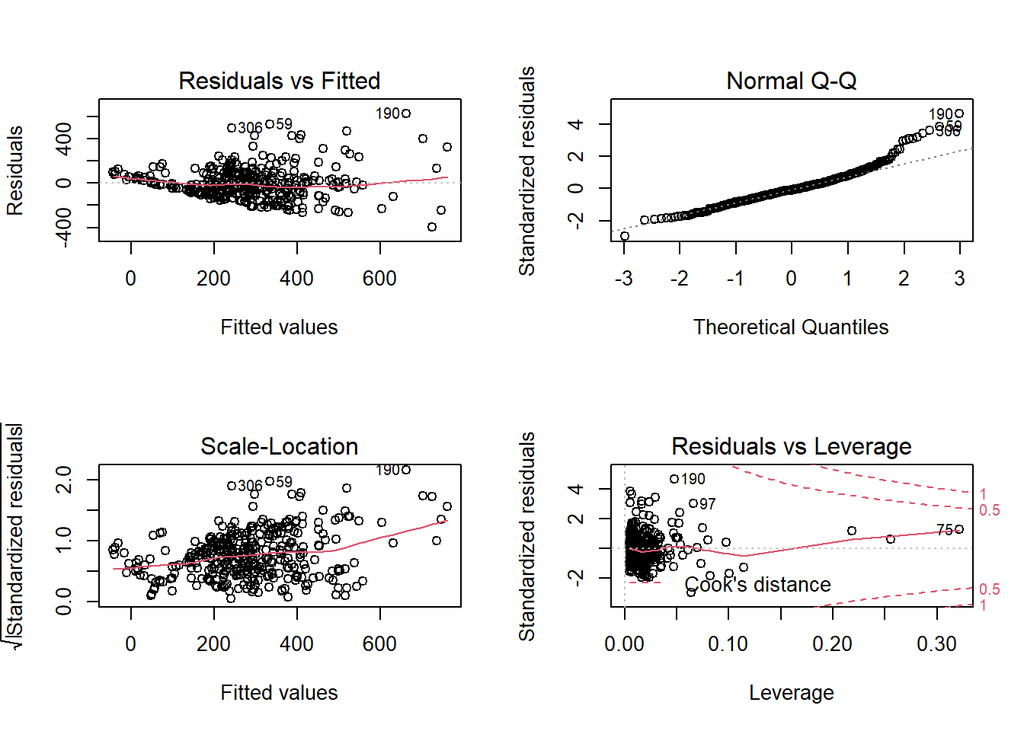

Apesar do resíduo estar em torno de 0, percebe-se que a variabilidade aumenta para os valores das estimativas que são maiores. Além dessa questão da variabilidade, observa-se um problema quanto a normalidade dos resíduos que, para este modelo, apresenta caudas pesadas.

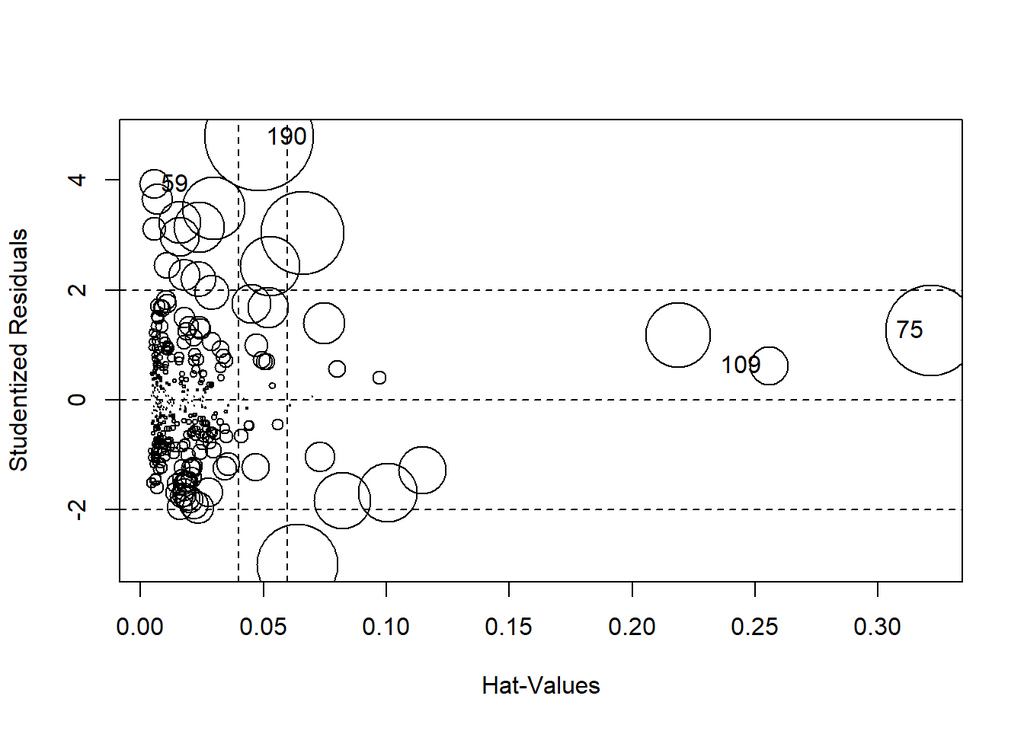

```
##       StudRes        Hat      CookD
## 59  3.9330778 0.00533924 0.01138489
## 75  1.2666769 0.32152426 0.10843085
## 109 0.6276498 0.25549674 0.01934724
## 190 4.7888620 0.04812669 0.15574192
```

```r
# Medidas de influencia
influencePlot(m0)
```

```r
# qqnorm com envelope.
```

A função `influencePlot()` detecta observações problemáticas com base em três medidas, são elas: *StudRes* (Resíduo Studentizado), *Hat* (y chapéu) e *CookD* (Distância de Cook).

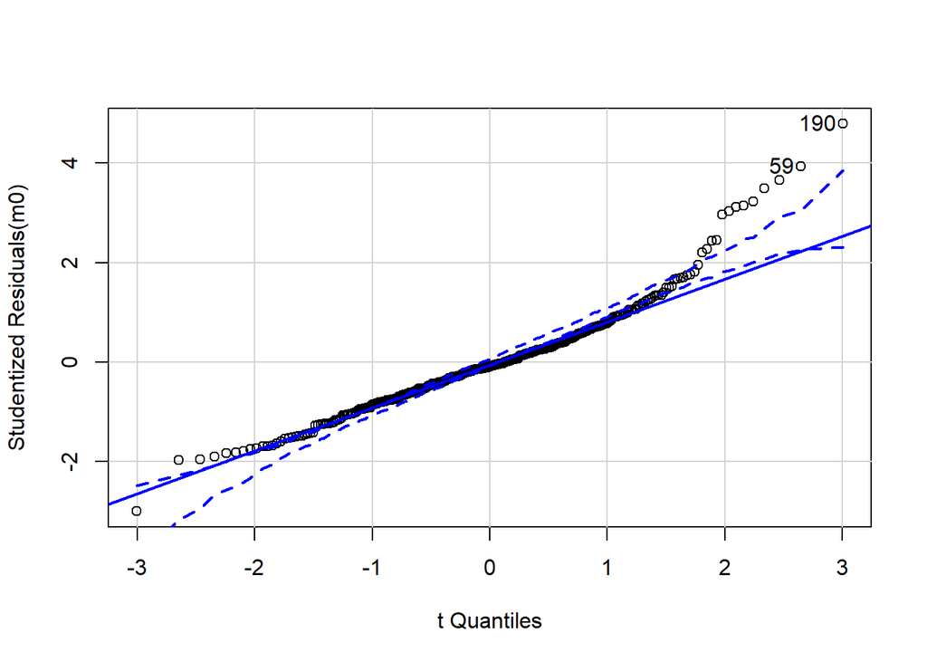

```
## [1]  59 190
```

```r
qqPlot(m0)
```

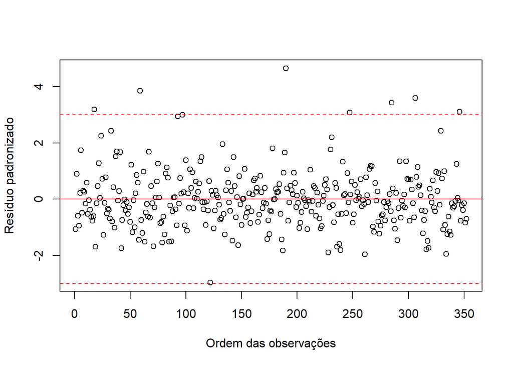

```r
# Resíduo padronizado
plot(rstandard(m0),
     xlab = "Ordem das observações",
     ylab = "Resíduo padronizado")
abline(h = c(-3, 3), col = "red", lty = 2)
abline(h = 0, col = "red", lty = 1)
```

Para tentar entender a questão da normalidade do modelo m0 foram utilizadas as funções `qqPlot()` e `rstandard()`, o critério para selecionar observações problemáticas foi não pertencer ao intervalo [-3,3].

Desse modo, as observações 18, 59, 190, 247, 285, 306 e 346 foram analisadas quanto a normalidade e optou-se por removê-las.

```r
### Modelo m1
dados1 <- filter(dados0[-c(18, 59, 190, 247, 285, 306, 346),], Preco > 0)
m1 <- lm(Preco ~ Avaliacao + Dias + nAvaliacao + Paginas + Idioma + TipoLivro, data = dados1)
summary(m1)
```

```
##
## Call:
## lm(formula = Preco ~ Avaliacao + Dias + nAvaliacao + Paginas +
##     Idioma + TipoLivro, data = dados1)
##
## Residuals:
##     Min      1Q  Median      3Q     Max
## -344.26  -75.18   -5.72   65.64  432.75
##
## Coefficients:
##                       Estimate  Std. Error t value             Pr(>|t|)
## (Intercept)         171.292920   67.964479   2.520               0.0122 *
## Avaliacao           -15.624503   15.931475  -0.981               0.3274
## Dias                 -0.003233    0.003367  -0.960               0.3376
## nAvaliacao           -0.079048    0.016402  -4.820          0.000002178 ***
## Paginas               0.471496    0.035021  13.463 < 0.0000000000000002 ***
## IdiomaPortugues    -194.368964   20.116338  -9.662 < 0.0000000000000002 ***
## TipoLivroCapa dura   90.455672   17.289261   5.232          0.000000295 ***
## ---
## Signif. codes:  0 '***' 0.001 '**' 0.01 '*' 0.05 '.' 0.1 ' ' 1
##
## Residual standard error: 119.5 on 338 degrees of freedom
## Multiple R-squared:  0.5245, Adjusted R-squared:  0.5161
## F-statistic: 62.15 on 6 and 338 DF,  p-value: < 0.00000000000000022
```

Após a exclusão de algumas observações o coeficientes de determinação do modelo m1 aumentou quando comparado ao modelo m0. As variáveis com p-valor acima de 0,05 permaneceram as mesmas.

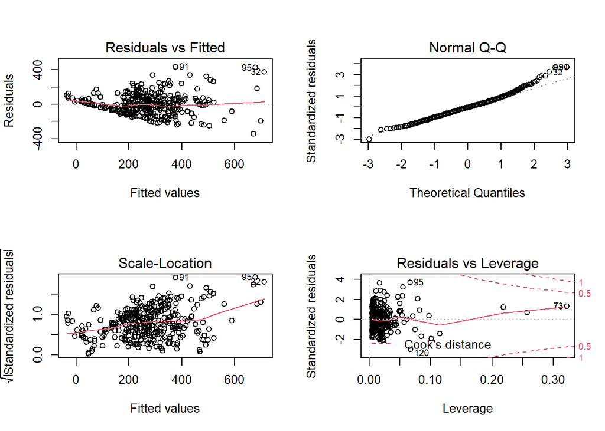

```r
### Análise diagnóstico
# Graficos
par(mfrow = c(2, 2))
plot(m1)
```

```r
layout(1)
```

A normalidade dos resíduos também é um problema para o modelo m1. O critério para a seleção permaneceu o mesmo e as observações 32, 91 e 95 foram analisadas.

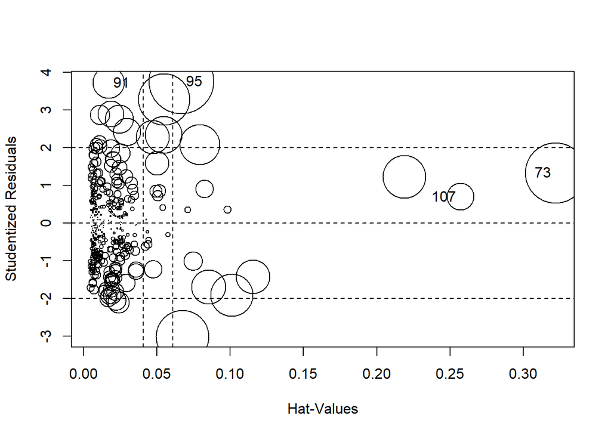

```
##       StudRes        Hat      CookD
## 73  1.3297757 0.32203808 0.11972217
## 91  3.7198335 0.01705816 0.03304946
## 95  3.7558379 0.06673243 0.13871533
## 107 0.6981254 0.25718688 0.02414333
```

```r
# Medidas de influencia
influencePlot(m1)
```

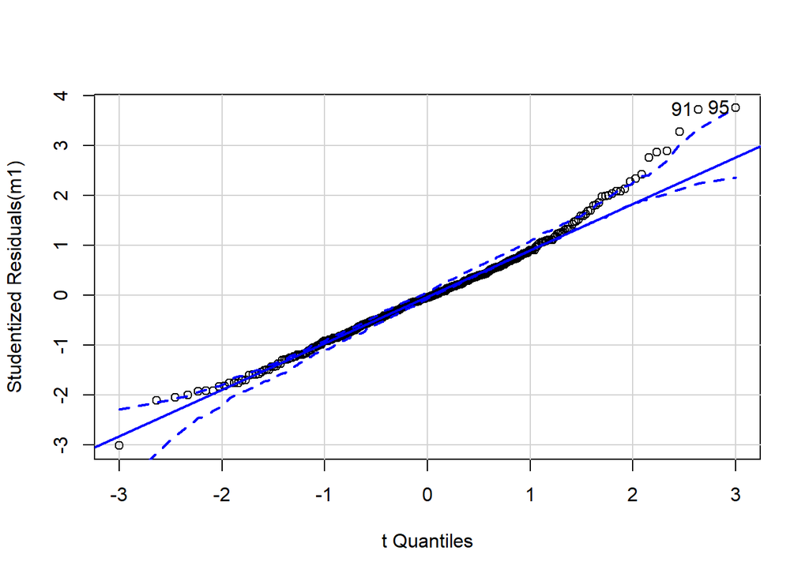

```
## [1] 91 95
```

```r
# qqnorm com envelope.
qqPlot(m1)
```

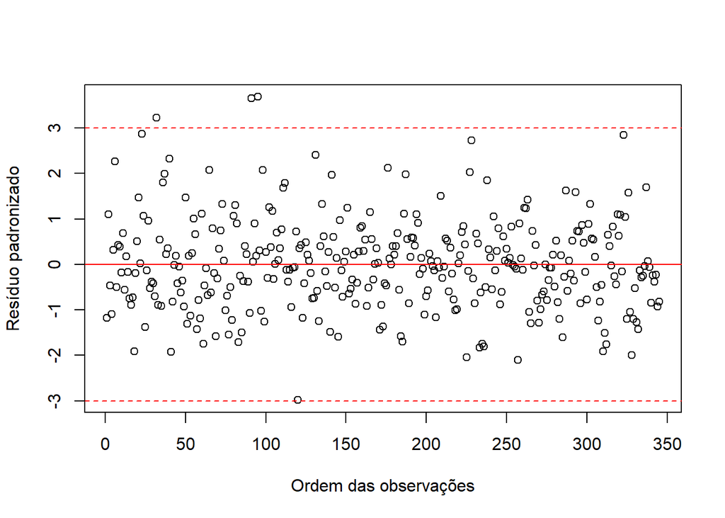

```r
# Resíduo padronizado
plot(rstandard(m1),
     xlab = "Ordem das observações",
     ylab = "Resíduo padronizado")
abline(h = c(-3, 3), col = "red", lty = 2)
abline(h = 0, col = "red", lty = 1)
```

Feita a análise das observações que apresentaram problemas quanto a normalidade, foi construído o modelo m2 que não considera a presença destas observações.

```r
### Modelo m2
dados2 <- filter(dados1[-c(32, 91, 95),], Preco > 0)
m2 <- lm(Preco ~ Avaliacao + Dias + nAvaliacao + Paginas + Idioma + TipoLivro, data = dados2)
summary(m2)
```

```
##
## Call:
## lm(formula = Preco ~ Avaliacao + Dias + nAvaliacao + Paginas +
##     Idioma + TipoLivro, data = dados2)
##
## Residuals:
##     Min      1Q  Median      3Q     Max
## -306.72  -75.43   -3.01   68.42  356.04
##
## Coefficients:
##                       Estimate  Std. Error t value             Pr(>|t|)
## (Intercept)         190.964330   64.342037   2.968              0.00321 **
## Avaliacao           -16.461971   15.067039  -1.093              0.27536
## Dias                 -0.001686    0.003194  -0.528              0.59796
## nAvaliacao           -0.073895    0.015528  -4.759          0.000002899 ***
## Paginas               0.417583    0.034760  12.013 < 0.0000000000000002 ***
## IdiomaPortugues    -191.308626   19.022099 -10.057 < 0.0000000000000002 ***
## TipoLivroCapa dura   82.986035   16.541290   5.017          0.000000854 ***
## ---
## Signif. codes:  0 '***' 0.001 '**' 0.01 '*' 0.05 '.' 0.1 ' ' 1
##
## Residual standard error: 113 on 335 degrees of freedom
## Multiple R-squared:  0.4968, Adjusted R-squared:  0.4878
## F-statistic: 55.13 on 6 and 335 DF,  p-value: < 0.00000000000000022
```

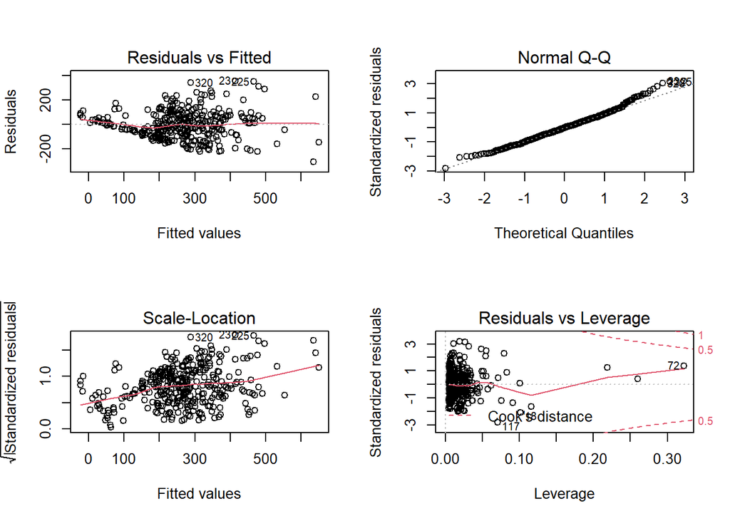

```r
### Análise diagnóstico
# Graficos
par(mfrow = c(2, 2))
plot(m2)
```

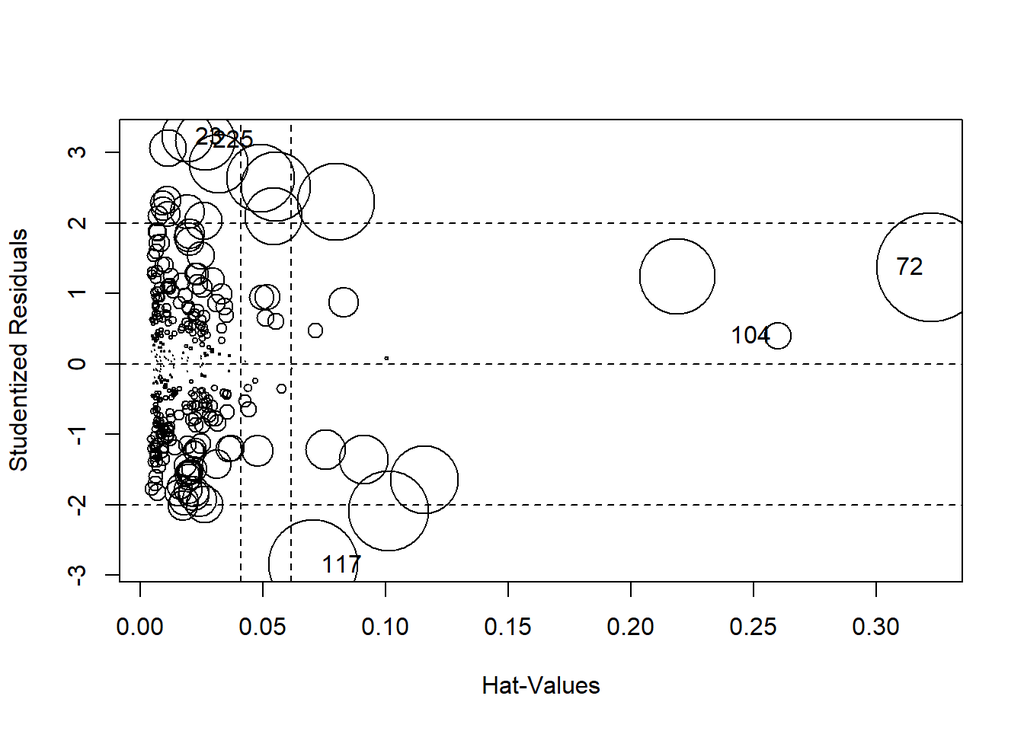

```
##        StudRes        Hat       CookD
## 23   3.2269250 0.01934178 0.028538006
## 72   1.3731286 0.32227381 0.127746407
## 104  0.4031176 0.25996409 0.008175477
## 117 -2.8459339 0.07055693 0.086012394
## 225  3.1791199 0.02643450 0.038165699
```

```r
layout(1)
# Medidas de influencia
influencePlot(m2)
```

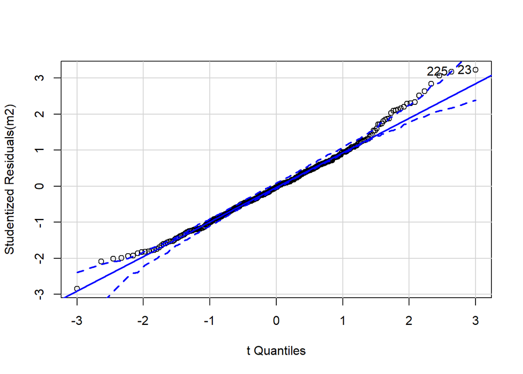

```
## [1]  23 225
```

```r
# qqnorm com envelope.
qqPlot(m2)
```

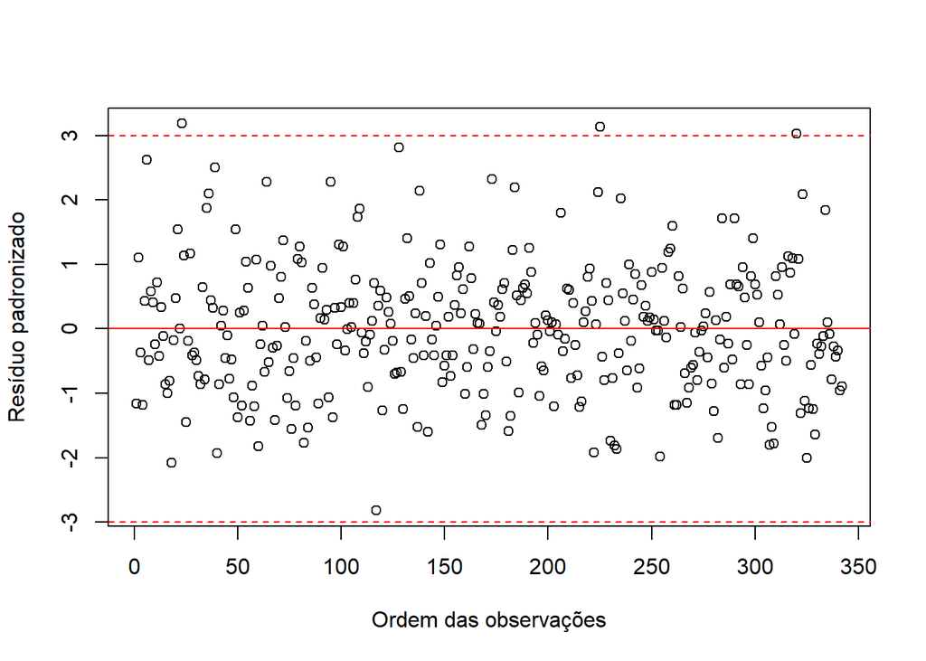

```r
# Resíduo padronizado
plot(rstandard(m2),
     xlab = "Ordem das observações",
     ylab = "Resíduo padronizado")
abline(h = c(-3, 3), col = "red", lty = 2)
abline(h = 0, col = "red", lty = 1)
```

Em m2 os resíduos tiveram um melhor ajuste quanto a normalidade, porém algumas observações ainda não atendem ao critério de terem o resíduo padronizado no intervalo [-3,3].  
Foram identificados problemas nas observações 23, 225, 320.

```r
### Modelo m3
dados3 <- filter(dados2[-c(23, 225, 320),], Preco > 0)
m3 <- lm(Preco ~ Avaliacao + Dias + nAvaliacao + Paginas + Idioma + TipoLivro, data = dados3)
summary(m3)
```

```
##
## Call:
## lm(formula = Preco ~ Avaliacao + Dias + nAvaliacao + Paginas +
##     Idioma + TipoLivro, data = dados3)
##
## Residuals:
##     Min      1Q  Median      3Q     Max
## -288.95  -72.57   -1.71   71.43  325.12
##
## Coefficients:
##                       Estimate  Std. Error t value             Pr(>|t|)
## (Intercept)         202.832945   61.925977   3.275              0.00117 **
## Avaliacao           -18.375994   14.514121  -1.266              0.20637
## Dias                 -0.002144    0.003073  -0.698              0.48586
## nAvaliacao           -0.069763    0.014919  -4.676          0.000004256 ***
## Paginas               0.400907    0.033718  11.890 < 0.0000000000000002 ***
## IdiomaPortugues    -187.391654   18.270618 -10.256 < 0.0000000000000002 ***
## TipoLivroCapa dura   81.436810   15.997780   5.091          0.000000599 ***
## ---
## Signif. codes:  0 '***' 0.001 '**' 0.01 '*' 0.05 '.' 0.1 ' ' 1
##
## Residual standard error: 108.4 on 332 degrees of freedom
## Multiple R-squared:  0.4997, Adjusted R-squared:  0.4907
## F-statistic: 55.27 on 6 and 332 DF,  p-value: < 0.00000000000000022
```

Assim como nos modelos anteriores, e com base no teste t, as variáveis *Avaliacao* e *Dias* são as menos significativas para a predição do preço dos livros.

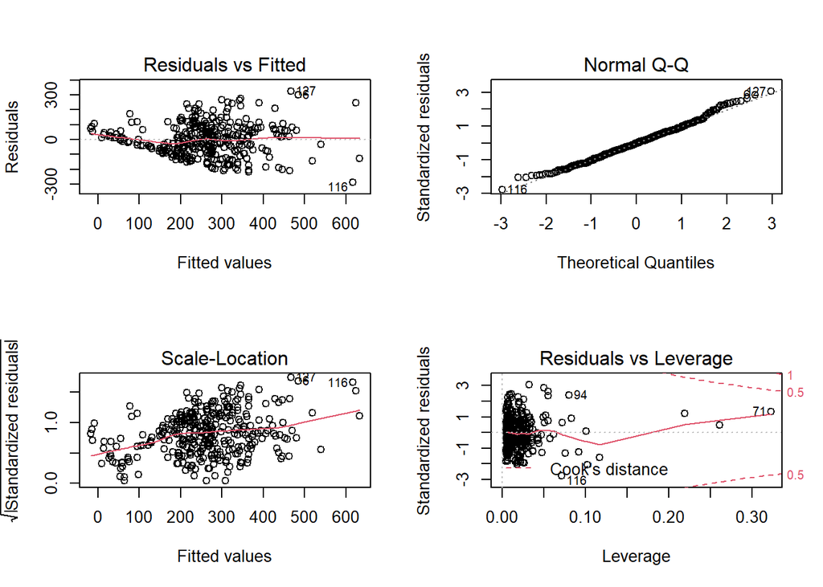

```r
### Análise diagnóstico
# Graficos
par(mfrow = c(2, 2))
plot(m3)
```

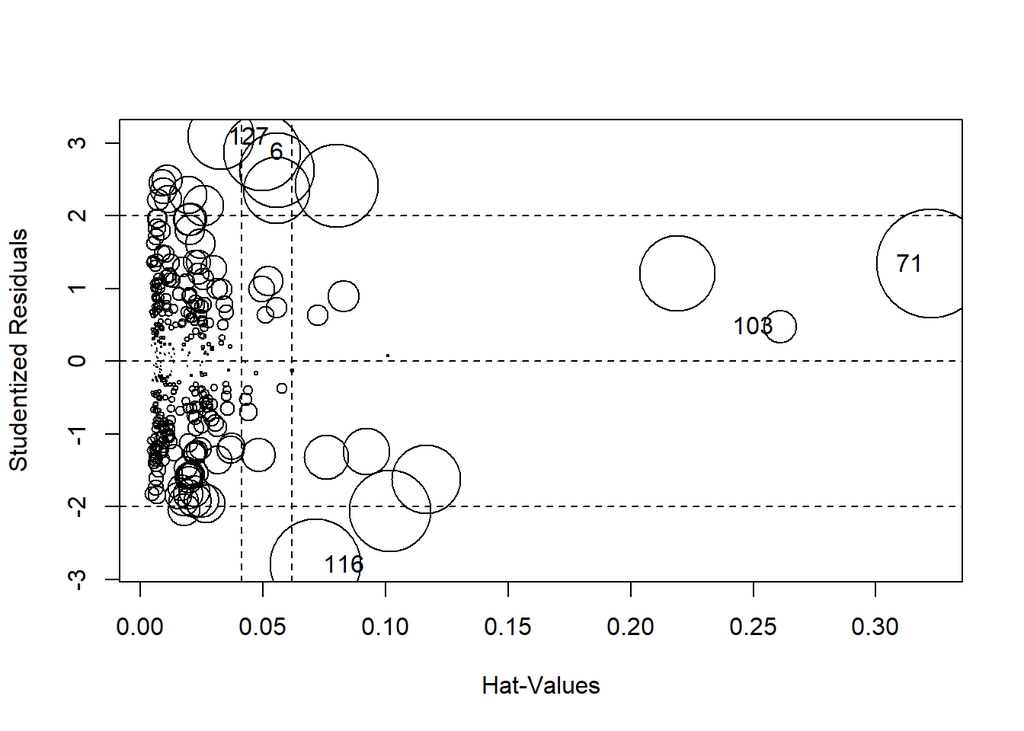

```
##        StudRes        Hat      CookD
## 6    2.8780933 0.04980316 0.06069186
## 71   1.3387516 0.32250795 0.12159145
## 103  0.4781629 0.26115497 0.01157201
## 116 -2.7946108 0.07162374 0.08434505
## 127  3.0885406 0.03280042 0.04505501
```

```r
layout(1)
# Medidas de influencia
influencePlot(m3)
```

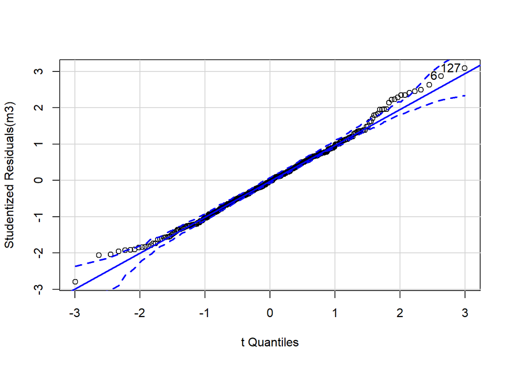

```
## [1]   6 127
```

```r
# qqnorm com envelope.
qqPlot(m3)
```

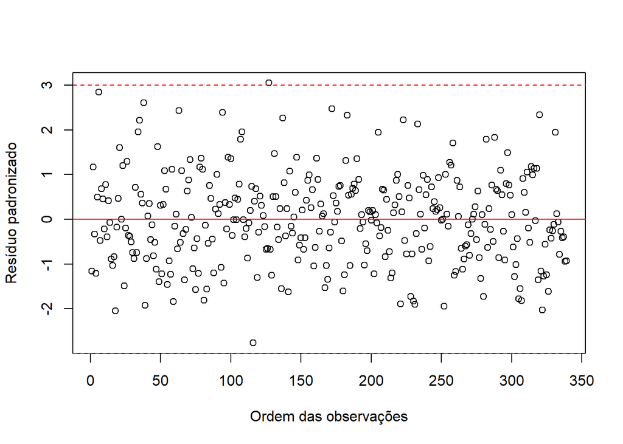

```r
# Resíduo padronizado
plot(rstandard(m3),
     xlab = "Ordem das observações",
     ylab = "Resíduo padronizado")
abline(h = c(-3, 3), col = "red", lty = 2)
abline(h = 0, col = "red", lty = 1)
```

O modelo m3 apresenta resultados semelhantes aos de m2.  
Em m3 as observações 71 e 127 são analisadas por apresentarem problemas, a primeira por questão de alavancagem e a segunda por normalidade.

```r
### Modelo m4
dados4 <- filter(dados3[-c(71,127),], Preco > 0)
m4 <- lm(Preco ~ Avaliacao + Dias + nAvaliacao + Paginas + Idioma + TipoLivro, data = dados4)
summary(m4)
```

```
##
## Call:
## lm(formula = Preco ~ Avaliacao + Dias + nAvaliacao + Paginas +
##     Idioma + TipoLivro, data = dados4)
##
## Residuals:
##     Min      1Q  Median      3Q     Max
## -276.50  -73.27   -3.20   72.46  311.88
##
## Coefficients:
##                       Estimate  Std. Error t value             Pr(>|t|)
## (Intercept)         199.815203   61.176676   3.266               0.0012 **
## Avaliacao           -15.845328   14.369990  -1.103               0.2710
## Dias                 -0.002188    0.003031  -0.722               0.4709
## nAvaliacao           -0.084451    0.017754  -4.757          0.000002946 ***
## Paginas               0.381973    0.033705  11.333 < 0.0000000000000002 ***
## IdiomaPortugues    -186.205622   18.023636 -10.331 < 0.0000000000000002 ***
## TipoLivroCapa dura   83.874567   15.791935   5.311          0.000000201 ***
## ---
## Signif. codes:  0 '***' 0.001 '**' 0.01 '*' 0.05 '.' 0.1 ' ' 1
##
## Residual standard error: 106.9 on 330 degrees of freedom
## Multiple R-squared:  0.4984, Adjusted R-squared:  0.4893
## F-statistic: 54.66 on 6 and 330 DF,  p-value: < 0.00000000000000022
```

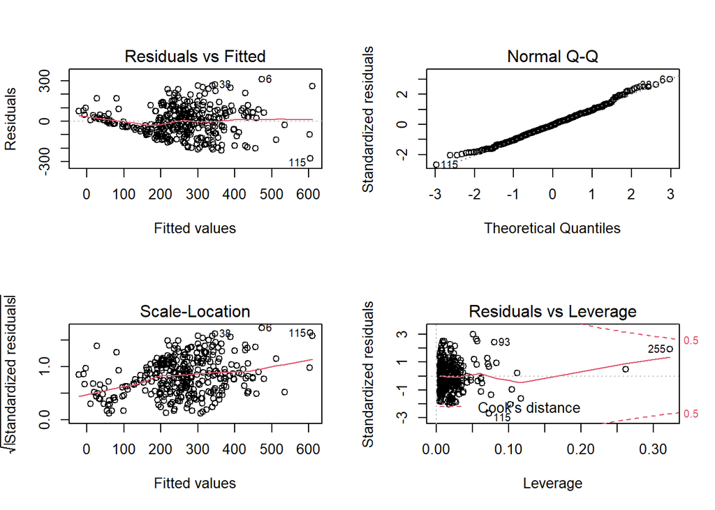

```r
### Análise diagnóstico
# Graficos
par(mfrow = c(2, 2))
plot(m4)
```

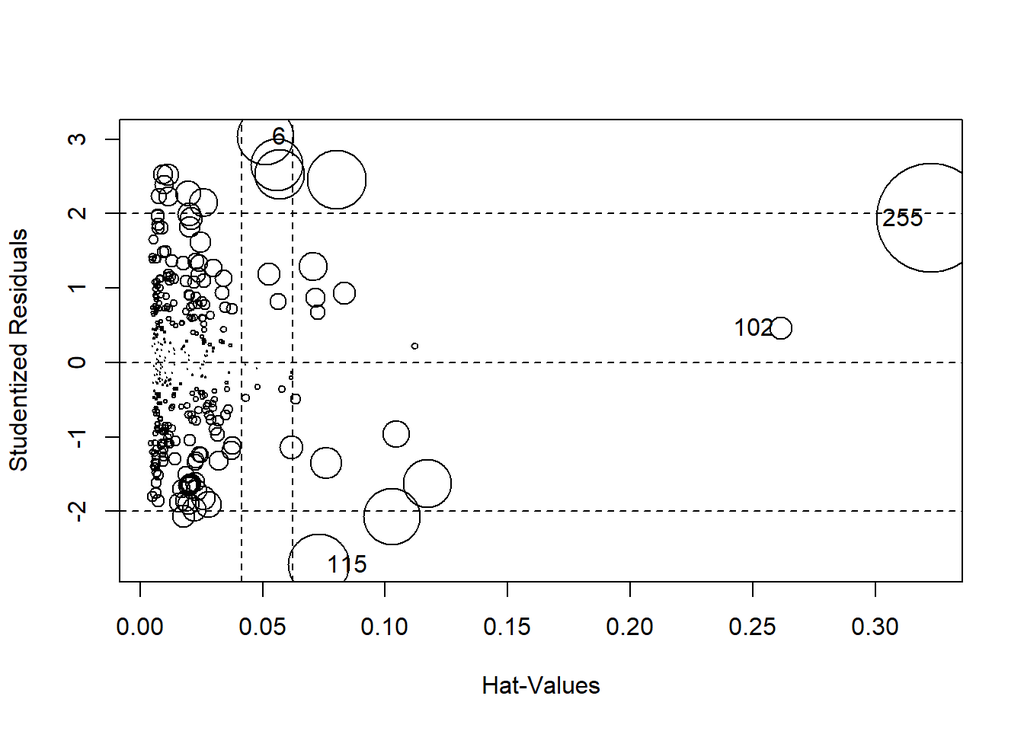

```
##        StudRes        Hat      CookD
## 6    3.0327884 0.05089122 0.06874739
## 102  0.4624975 0.26164659 0.01085444
## 115 -2.7129609 0.07283467 0.08103626
## 255  1.9417727 0.32278883 0.25460227
```

```r
layout(1)
# Medidas de influencia
influencePlot(m4)
```

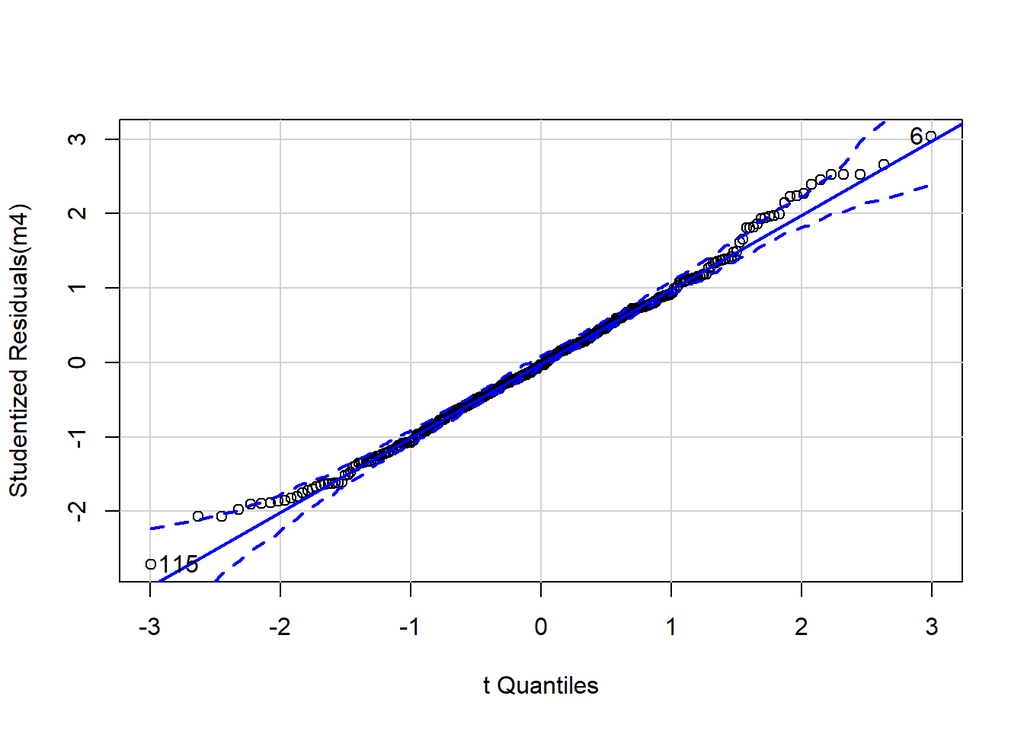

```
## [1]   6 115
```

```r
# qqnorm com envelope.
qqPlot(m4)
```

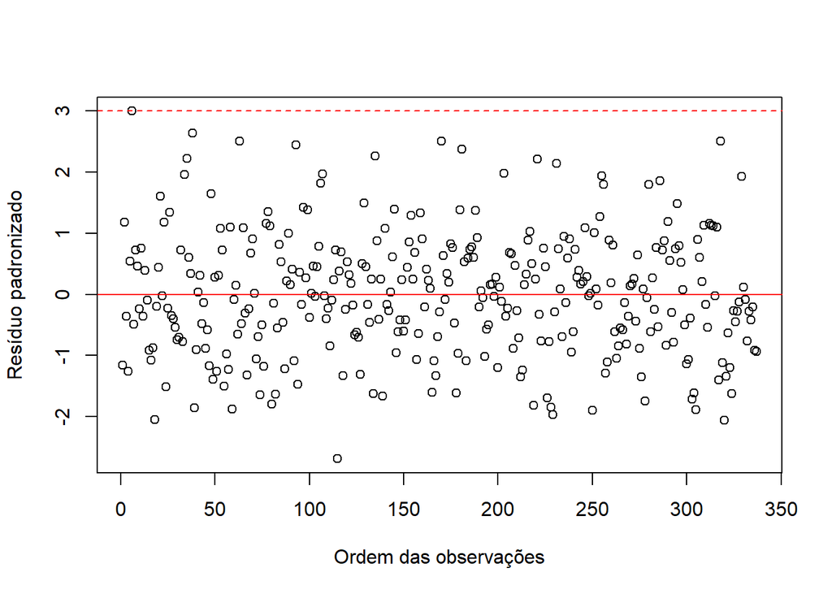

```r
# Resíduo padronizado
plot(rstandard(m4),
     xlab = "Ordem das observações",
     ylab = "Resíduo padronizado")
abline(h = c(-3, 3), col = "red", lty = 2)
abline(h = 0, col = "red", lty = 1)
```

O modelo m4 tem um ajuste melhor, porém ainda há alguns problemas de normalidade e alavancagem nas observações, são elas: 6, 115 e 255.

```r
### Modelo m5
dados5 <- filter(dados4[-c(6, 115, 255),], Preco > 0)
m5 <- lm(Preco ~ Avaliacao + Dias + nAvaliacao + Paginas + Idioma + TipoLivro, data = dados5)
summary(m5)
```

```
##
## Call:
## lm(formula = Preco ~ Avaliacao + Dias + nAvaliacao + Paginas +
##     Idioma + TipoLivro, data = dados5)
##
## Residuals:
##      Min       1Q   Median       3Q      Max
## -220.038  -69.910   -3.379   68.368  272.435
##
## Coefficients:
##                       Estimate  Std. Error t value             Pr(>|t|)
## (Intercept)         184.716698   60.092015   3.074              0.00229 **
## Avaliacao           -12.110890   14.230468  -0.851              0.39536
## Dias                 -0.001514    0.002995  -0.505              0.61363
## nAvaliacao           -0.106755    0.020961  -5.093         0.0000005963 ***
## Paginas               0.380070    0.033965  11.190 < 0.0000000000000002 ***
## IdiomaPortugues    -185.782480   17.589377 -10.562 < 0.0000000000000002 ***
## TipoLivroCapa dura   89.820631   15.483111   5.801         0.0000000155 ***
## ---
## Signif. codes:  0 '***' 0.001 '**' 0.01 '*' 0.05 '.' 0.1 ' ' 1
##
## Residual standard error: 104.2 on 327 degrees of freedom
## Multiple R-squared:  0.5087, Adjusted R-squared:  0.4997
## F-statistic: 56.43 on 6 and 327 DF,  p-value: < 0.00000000000000022
```

Após a remoção de algumas observações problemáticas, o modelo m5 contém 6 variáveis e 334 observações.

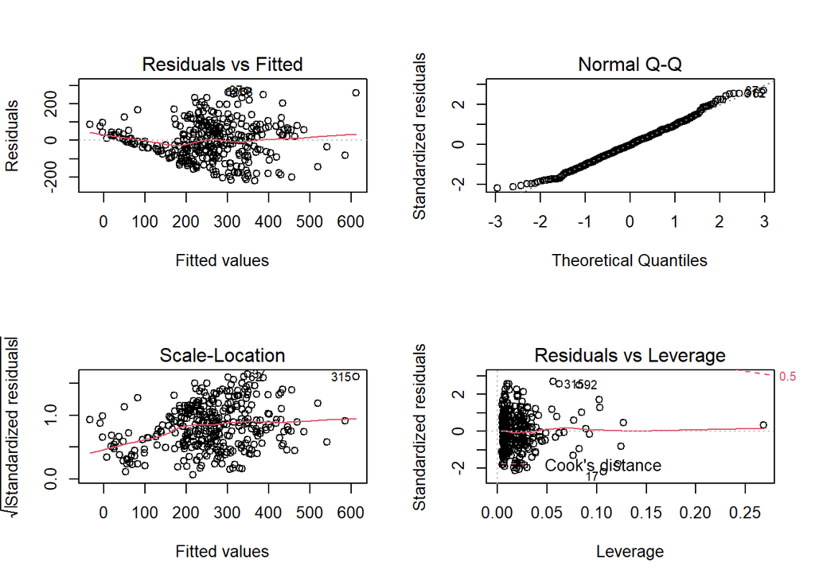

```r
### Análise diagnóstico
# Graficos
par(mfrow = c(2, 2))
plot(m5)
```

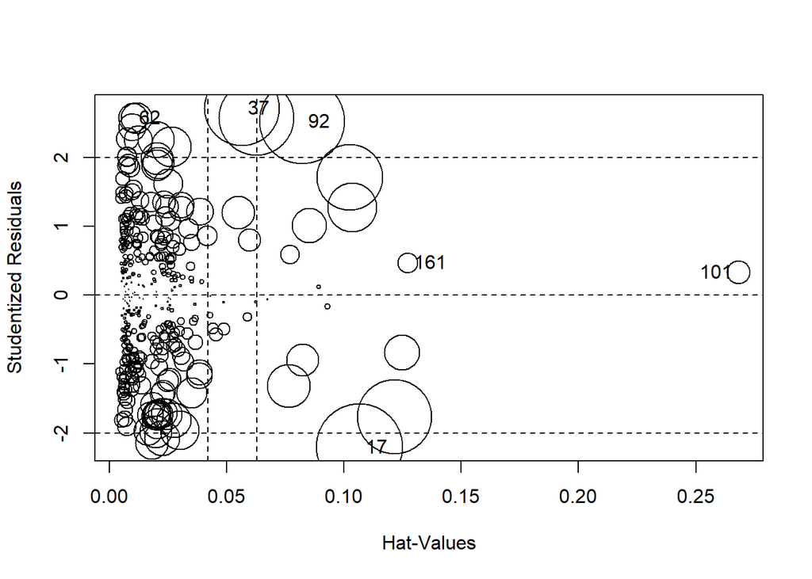

```
##        StudRes        Hat       CookD
## 17  -2.2075818 0.10673250 0.082212265
## 37   2.7175824 0.05641897 0.061874930
## 62   2.5793828 0.01011042 0.009542717
## 92   2.5262425 0.08228620 0.080423351
## 101  0.3370669 0.26810407 0.005961658
## 161  0.4710972 0.12723689 0.004633127
```

```r
layout(1)
# Medidas de influencia
influencePlot(m5)
```